# Prosper Loan Data

This project analyses a data set which contains 113,937 loans with 81 variables on each loan, including loan amount, borrower rate (or interest rate), current loan status, borrower income, and many others.

This Project gives an overview of the performance of the Bank, with general trends for Loan, its availers and the type of loans availed being looked into. Certain inter relations are also being looked into

#### Exploratory Data Analysis

###### Univariate Distributions

Initially all the quantitative variables would be checked and then we'll proceed to categorical variables

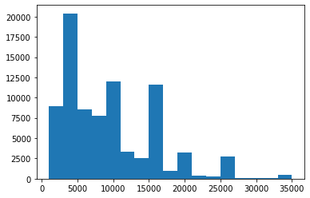

```python
# LoanOriginalAmount
bins=np.arange(1000, df['LoanOriginalAmount'].max()+1000, 2000)
#bins= 10**np.arange(3, 5+.1, 0.1)
plt.hist(data=df, x='LoanOriginalAmount', bins=bins);
#plt.xscale('log')
```

A multi modal distribution in which a Loan Amount of less than $10000 was the highest.

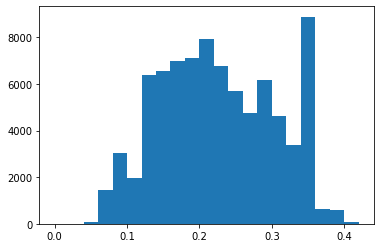

```python
# BorrowerAPR
bins=np.arange(0, df['BorrowerAPR'].max()+0.01, .02)
plt.hist(data=df, x='BorrowerAPR', bins=bins);
```

Normal distribution with an anomaly at somewhere around 0.35 where it peaks

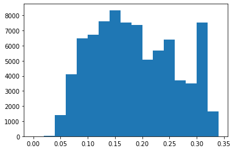

```python
# LenderYield
bins=np.arange(0, df['LenderYield'].max()+0.01, .02)
#bins= np.arange(3, 5+.1, 0.1)
plt.hist(data=df, x='LenderYield', bins=bins);
#plt.xscale('log')
```

Similar distribution to that of BorrowerAPR

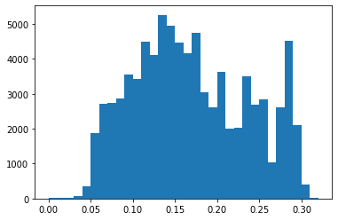

```python
# EstimatedEffectiveYield
bins=np.arange(0, df['EstimatedEffectiveYield'].max()+0.01, .01)
#bins= np.arange(3, 5+.1, 0.1)
plt.hist(data=df, x='EstimatedEffectiveYield', bins=bins);
#plt.xscale('log')
```

Normal distribution at around 0.15

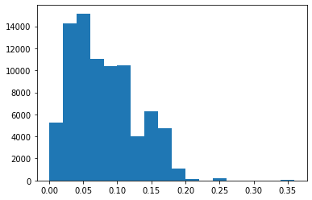

```python
# EstimatedLoss
bins=np.arange(0, df['EstimatedLoss'].max()+0.01, .02)
#bins= np.arange(3, 5+.1, 0.1)
plt.hist(data=df, x='EstimatedLoss', bins=bins);
#plt.xscale('log')
#plt.xlim(0.2)
```

Normal distribution with right skew

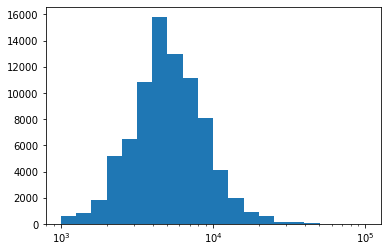

```python
# StatedMonthlyIncome
#bins=np.arange(1000, df['StatedMonthlyIncome'].max()+1000, 2000)
bins= 10**np.arange(3, 5+.1, 0.1)
plt.hist(data=df, x='StatedMonthlyIncome', bins=bins);
plt.xscale('log')
```

The log distribution gave a normal distribution for the plot

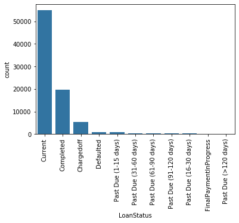

```python
# LoanStatus
order= df.LoanStatus.value_counts().index
base_color= sb.color_palette()[0]
sb.countplot(data=df, x='LoanStatus', color=base_color, order=order);
plt.xticks(rotation=90);
```

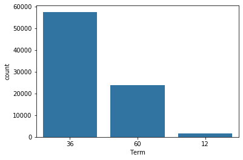

```python
# Term
order= df.Term.value_counts().index
base_color= sb.color_palette()[0]
sb.countplot(data=df, x='Term', color=base_color, order=order);
```

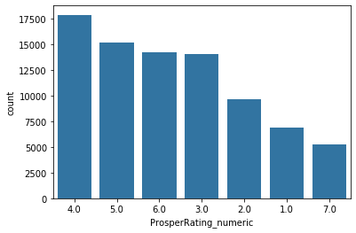

```python
# ProsperRating_numeric
order= df.ProsperRating_numeric.value_counts().index
base_color= sb.color_palette()[0]
sb.countplot(data=df, x='ProsperRating_numeric', color=base_color, order=order);
```